# Análisis exploratorio

Abraham Cruz-Mendívil

2025-07-01

Instalar paquetes (sólo la primera vez)

```r
# install.packages("tidyverse")
# install.packages("cowplot")
# install.packages("viridis")
# install.packages("BiocManager")
# BiocManager::install("tximport")
# BiocManager::install("DESeq2")
```

Cargar paquetes (cada vez que inicie sesión en R)

```r
library(cowplot)
library(viridis)
library(tximport)
library(DESeq2)
library(tidyverse)
```

## 1. Importación de archivos

### 1.1. Importar archivos de conteos (kallisto)

```r
files <- list.files(full.names = TRUE,
                    path = "conteos crudos",
                    pattern = "*.tsv")
files
```

```
##  [1] "conteos crudos/SRR22534049.tsv" "conteos crudos/SRR22534050.tsv"
##  [3] "conteos crudos/SRR22534051.tsv" "conteos crudos/SRR22534058.tsv"
##  [5] "conteos crudos/SRR22534059.tsv" "conteos crudos/SRR22534060.tsv"
##  [7] "conteos crudos/SRR6665368.tsv"  "conteos crudos/SRR6665369.tsv"
##  [9] "conteos crudos/SRR6665370.tsv"  "conteos crudos/SRR6665371.tsv"
## [11] "conteos crudos/SRR6665373.tsv"  "conteos crudos/SRR6665376.tsv"
```

### 1.2. Importar metadatos con información de los bioproyectos

```r
metadatos <- read.csv("~/Desktop/Meta-analisis transcriptomico/4/metadata_all.csv", sep=";")
head(metadatos)
```

```
##           Run  BioProject  genotype            Instrument tissue treatment  BP
## 1 SRR22534049 PRJNA908834 Wild type Illumina NovaSeq 6000   leaf   control BP1
## 2 SRR22534050 PRJNA908834 Wild type Illumina NovaSeq 6000   leaf   control BP1
## 3 SRR22534051 PRJNA908834 Wild type Illumina NovaSeq 6000   leaf   control BP1
## 4 SRR22534058 PRJNA908834 Wild type Illumina NovaSeq 6000   leaf   drought BP1
## 5 SRR22534059 PRJNA908834 Wild type Illumina NovaSeq 6000   leaf   drought BP1
## 6 SRR22534060 PRJNA908834 Wild type Illumina NovaSeq 6000   leaf   drought BP1
##   batch     replicates  conditions
## 1     1 BP1_control_r1 BP1_control
## 2     1 BP1_control_r2 BP1_control
## 3     1 BP1_control_r3 BP1_control
## 4     1 BP1_drought_r1 BP1_drought
## 5     1 BP1_drought_r2 BP1_drought
## 6     1 BP1_drought_r3 BP1_drought
```

Verificar que número de elementos en files = número de filas en metadatos

```r
length(files) == nrow(metadatos)
```

```
## [1] TRUE
```

### 1.3. Importar equivalencia de IDs de transcritos y genes.

Este archivo se obtiene de Ensembl Biomart https://plants.ensembl.org/info/data/biomart/index.html

Nota: La información de gene start, gene end y go term, se usarán en el análisis de sobre-representación de categorías funcionales.

Este procedimiento puede repetirse para otros organismos disponibles en Ensembl.

Importar archivo descargado de biomart.

```r
biomart <- read.delim("mart_export_ZM.txt")
head(biomart)
```

```
##    Gene.stable.ID Transcript.stable.ID Gene.start..bp. Gene.end..bp.
## 1 Zm00001eb442760 Zm00001eb442760_T001           10521         11826
## 2 Zm00001eb393960 Zm00001eb393960_T001       132291376     132291533
## 3 Zm00001eb393960 Zm00001eb393960_T001       132291376     132291533
## 4 Zm00001eb393960 Zm00001eb393960_T001       132291376     132291533
## 5 Zm00001eb113450 Zm00001eb113450_T001       230473563     230476257
## 6 Zm00001eb437000 Zm00001eb437000_T002          107286        111059
##   GO.term.accession
## 1
## 2        GO:0030627
## 3        GO:0000395
## 4        GO:0005685
## 5
## 6
```

Formatear el archivo de equivalencias de IDs de genes y transcritos

```r
t2g <- biomart %>%
  rename(gene = Gene.stable.ID, transcript = Transcript.stable.ID) %>%
  select (transcript, gene) %>%
  distinct(transcript, .keep_all = T)
head(t2g)
```

```
##             transcript            gene
## 1 Zm00001eb442760_T001 Zm00001eb442760
## 2 Zm00001eb393960_T001 Zm00001eb393960
## 3 Zm00001eb113450_T001 Zm00001eb113450
## 4 Zm00001eb437000_T002 Zm00001eb437000
## 5 Zm00001eb437000_T001 Zm00001eb437000
## 6 Zm00001eb441340_T001 Zm00001eb441340
```

Combinar archivos de conteos y resumir expresion a nivel de gen

```r
txi.kallisto <- tximport(files,
                         type = "kallisto",
                         tx2gene = t2g)
```

```
## Note: importing `abundance.h5` is typically faster than `abundance.tsv`
```

```
## reading in files with read_tsv
```

```
## 1 2 3 4 5 6 7 8 9 10 11 12
## summarizing abundance
## summarizing counts
## summarizing length
```

Definir un objeto DESeq2 a partir de los conteos de kallisto

```r
# design = columna de metadatos que usaremos para los contrastes
dds <- DESeqDataSetFromTximport(txi.kallisto,
                                colData = metadatos,
                                design = ~ conditions)
```

```
## using counts and average transcript lengths from tximport
```

```r
# Ver resumen del objeto dds
dds
```

```
## class: DESeqDataSet
## dim: 39756 12
## metadata(1): version
## assays(2): counts avgTxLength
## rownames(39756): Zm00001eb000010 Zm00001eb000020 ... Zm00001eb443020
##   Zm00001eb443030
## rowData names(0):
## colnames: NULL
## colData names(10): Run BioProject ... replicates conditions
```

Generar matriz de conteos crudos

```r
rawcounts <- as.matrix(counts(dds))
head(rawcounts)
```

```
##                 [,1] [,2] [,3] [,4] [,5] [,6] [,7] [,8] [,9] [,10] [,11] [,12]
## Zm00001eb000010   40   60   63   73   67   61  395  237  177   359   285   415
## Zm00001eb000020    7   11    2    3    3    5   59   32   31    95    59    54
## Zm00001eb000050    0    0    1    0    0    0   19    8   13    16    17    17
## Zm00001eb000060    0    0    0    0    2    0  295  149  191   379   296   236
## Zm00001eb000070   32   33   50   44   26   36    5    3    6     7    10     5
## Zm00001eb000080   93  119  137  107   97  131  242  133   75   165   137   214
```

```r
# Exportar archivo
write.csv(rawcounts, file = "resultados/rawcounts.csv", row.names = TRUE)
```

Filtrar genes con conteos promedio > 10 entre todas las muestras

```r
filtcounts <- rawcounts[rowMeans(rawcounts) > 10,]
head(filtcounts)
```

```
##                 [,1] [,2] [,3] [,4] [,5] [,6] [,7] [,8] [,9] [,10] [,11] [,12]
## Zm00001eb000010   40   60   63   73   67   61  395  237  177   359   285   415
## Zm00001eb000020    7   11    2    3    3    5   59   32   31    95    59    54
## Zm00001eb000060    0    0    0    0    2    0  295  149  191   379   296   236
## Zm00001eb000070   32   33   50   44   26   36    5    3    6     7    10     5
## Zm00001eb000080   93  119  137  107   97  131  242  133   75   165   137   214
## Zm00001eb000170  121  119  201  143  154  128  537  343  285   499   457   446
```

```r
filtcounts <- as.matrix(filtcounts)
todo_cero_g1 <- apply(filtcounts[, 1:6], 1, function(x) all(x == 0))
todo_cero_g2 <- apply(filtcounts[, 7:12], 1, function(x) all(x == 0))
filt_sin_ceros <- filtcounts[!todo_cero_g1 & !todo_cero_g2, ]

cat("Genes eliminados por ceros en todo grupo 1:", sum(todo_cero_g1), "\n")
```

```
## Genes eliminados por ceros en todo grupo 1: 704
```

```r
cat("Genes eliminados por ceros en todo grupo 2:", sum(todo_cero_g2), "\n")
```

```
## Genes eliminados por ceros en todo grupo 2: 6
```

```r
cat("Genes restantes:", nrow(filt_sin_ceros), "\n")
```

```
## Genes restantes: 22237
```

```r
filtcounts <- filt_sin_ceros
# Calcular que % de genes se expresan del total del genoma
p <- (nrow(filtcounts)/nrow(rawcounts))*100
paste("genes expresados =",round(p),"%")
```

```
## [1] "genes expresados = 56 %"
```

```r
# Exportar archivo
write.csv(filtcounts, file = "resultados/filtcounts.csv", row.names = TRUE)
```

Reemplazar objeto dds original con los genes filtrados

```r
# Extraer lista de genes expresados
expgen <- rownames(filtcounts)
# Reemplazar objeto dds original con los genes filtrados
dds <- dds[expgen,]
dds
```

```
## class: DESeqDataSet
## dim: 22237 12
## metadata(1): version
## assays(2): counts avgTxLength
## rownames(22237): Zm00001eb000010 Zm00001eb000020 ... Zm00001eb442780
##   Zm00001eb442940
## rowData names(0):
## colnames: NULL
## colData names(10): Run BioProject ... replicates conditions
```

## 2. Análisis exploratorio

Transformación de conteos con vst (variance-stabilizing transformation)

```r
vsd <- vst(dds, blind = FALSE)
```

```
## using 'avgTxLength' from assays(dds), correcting for library size
```

Análisis de componentes principales (PCA)

```r
# Obtener coordenadas para PCA
pcaData <- plotPCA(vsd, intgroup = "treatment", returnData = TRUE)
```

```
## using ntop=500 top features by variance
```

```r
head(pcaData)
```

```
##         PC1         PC2   group name         Run  BioProject  genotype
## 1 -50.78500  7.49313028 control    1 SRR22534049 PRJNA908834 Wild type
## 2 -48.53461 10.38035051 control    2 SRR22534050 PRJNA908834 Wild type
## 3 -48.37907 11.79092179 control    3 SRR22534051 PRJNA908834 Wild type
## 4 -44.40404  4.58257377 drought    4 SRR22534058 PRJNA908834 Wild type
## 5 -36.55965  0.09110521 drought    5 SRR22534059 PRJNA908834 Wild type
## 6 -27.76147 -8.34116008 drought    6 SRR22534060 PRJNA908834 Wild type
##              Instrument tissue treatment  BP batch     replicates  conditions
## 1 Illumina NovaSeq 6000   leaf   control BP1     1 BP1_control_r1 BP1_control
## 2 Illumina NovaSeq 6000   leaf   control BP1     1 BP1_control_r2 BP1_control
## 3 Illumina NovaSeq 6000   leaf   control BP1     1 BP1_control_r3 BP1_control
## 4 Illumina NovaSeq 6000   leaf   drought BP1     1 BP1_drought_r1 BP1_drought
## 5 Illumina NovaSeq 6000   leaf   drought BP1     1 BP1_drought_r2 BP1_drought
## 6 Illumina NovaSeq 6000   leaf   drought BP1     1 BP1_drought_r3 BP1_drought
```

```r
# Extraer % de variabilidad explicada por PC1 y PC2
percentVar <- round(100 * attr(pcaData, "percentVar"))
paste("Variabilidad explicada =", sum(percentVar), "%")
```

```
## [1] "Variabilidad explicada = 93 %"
```

Un PCA se considera adecuado si PC1 + PC2 explican > 70% de la variabilidad.

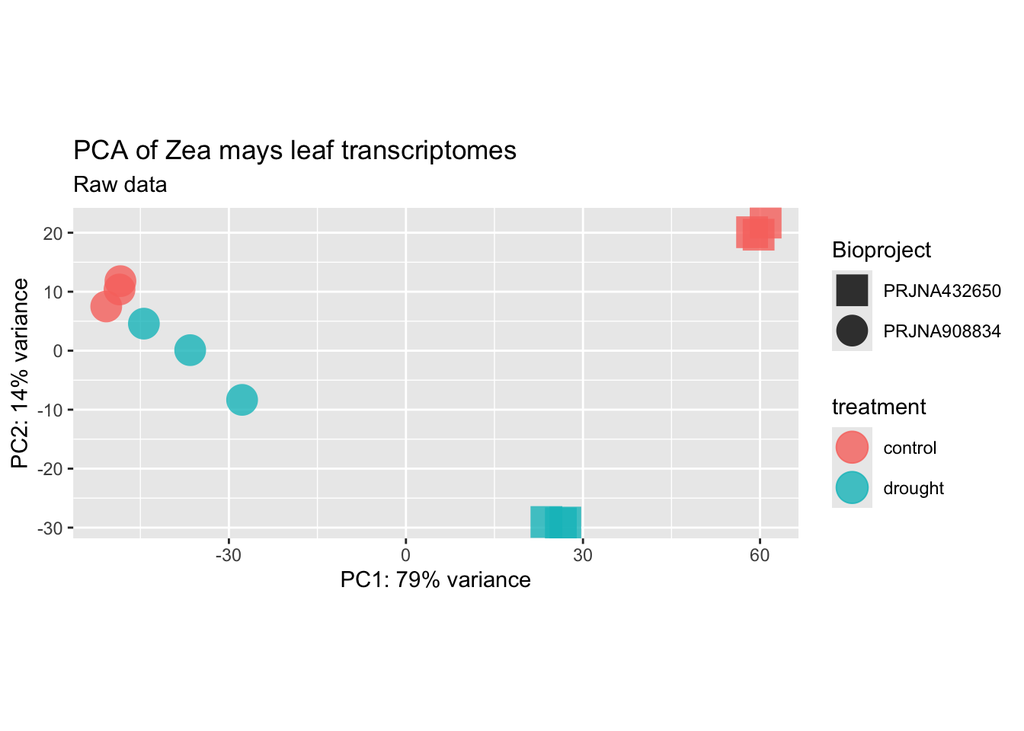

```r
#Generar gráfico PCA
pca <- ggplot(pcaData,
              aes(x = PC1,
                  y = PC2,
                  color = treatment,
                  shape = metadatos$BioProject)) +
  geom_point(size = 7, alpha = 0.8) +
  scale_shape_manual(values = 15:18) +
  labs(title = "PCA of Zea mays leaf transcriptomes",
       subtitle = "Raw data",
       x = paste0("PC1: ", percentVar[1], "% variance"),
       y = paste0("PC2: ", percentVar[2], "% variance"),
       color = "treatment",
       shape = "Bioproject") +
  coord_fixed()
pca
```

```r
ggsave(filename = "resultados/pca_raw.pdf", plot = pca, width = 11, height = 8.5)
```

Exportar objetos generados a archivo RData

```r
save(metadatos, dds, rawcounts, filtcounts, pca, file = "resultados/dds.RData")
```

Información de la sesión